# Saas/Ecommerce-cohort-retention & CLTV_Project

## Day 7- CLTV Visualization And Business Insights

```python
import pandas as pd
import numpy as np
import matplotlib.pyplot as plt
import seaborn as sns

pd.set_option("display.max_columns", None)

print("Libraries Imported Successfully")
```

```
Libraries Imported Successfully
```

```python
cltv_df = pd.read_csv(
    r"C:\Users\LENOVO\Desktop\Saas-Ecommerce-cohort-retention-CLTV_Project\data\processed\customer_cltv_segments.csv"
)

cltv_df.head()
```

|  | Customer ID | Revenue | Total_Orders | AOV | CLTV | CLTV_Segment |
| --- | --- | --- | --- | --- | --- | --- |
| 0 | 12346.0 | 77556.46 | 12 | 6463.038333 | 82187.988338 | A |
| 1 | 12347.0 | 4921.53 | 8 | 615.191250 | 7823.152003 | A |
| 2 | 12348.0 | 2019.40 | 5 | 403.880000 | 5135.987599 | B |
| 3 | 12349.0 | 4428.69 | 4 | 1107.172500 | 14079.489526 | A |
| 4 | 12350.0 | 334.40 | 1 | 334.400000 | 4252.436994 | B |

```python
cltv_df.shape
```

```
(5878, 6)
```

```python
# Dataset Information
cltv_df.info()
```

```
<class 'pandas.DataFrame'>
RangeIndex: 5878 entries, 0 to 5877
Data columns (total 6 columns):
 #   Column        Non-Null Count  Dtype
---  ------        --------------  -----
 0   Customer ID   5878 non-null   float64
 1   Revenue       5878 non-null   float64
 2   Total_Orders  5878 non-null   int64
 3   AOV           5878 non-null   float64
 4   CLTV          5878 non-null   float64
 5   CLTV_Segment  5878 non-null   str
dtypes: float64(4), int64(1), str(1)
memory usage: 275.7 KB
```

```python
# Missing Values Check
cltv_df.isnull().sum()
```

```
Customer ID     0
Revenue         0
Total_Orders    0
AOV             0
CLTV            0
CLTV_Segment    0
dtype: int64
```

```python
# CLTV Segment Distribution
cltv_df["CLTV_Segment"].value_counts()
```

```
CLTV_Segment
A    1470
D    1470
B    1469
C    1469
Name: count, dtype: int64
```

```python
# Percentage Distribution of Segments
round(
    cltv_df["CLTV_Segment"].value_counts(normalize=True) * 100,
    2
)
```

```
CLTV_Segment
A    25.01
D    25.01
B    24.99
C    24.99
Name: proportion, dtype: float64
```

```python
# Average CLTV By Segment
cltv_df.groupby("CLTV_Segment")["CLTV"].mean().sort_values(ascending=False)
```

```
CLTV_Segment
A    10865.444078
B     4309.806744
C     2867.581517
D     1548.176187
Name: CLTV, dtype: float64
```

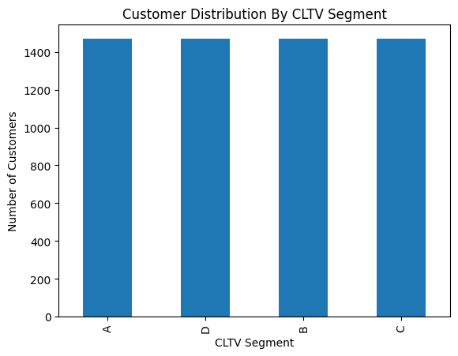

```python
# Customer Distribution Across CLTV Segments

# This visualization shows how customers are distributed across CLTV segments.
segment_counts = cltv_df["CLTV_Segment"].value_counts()

segment_counts.plot(kind="bar")

plt.title("Customer Distribution By CLTV Segment")
plt.xlabel("CLTV Segment")
plt.ylabel("Number of Customers")

plt.show()
```

```python
# Revenue Contribution By CLTV Segment
segment_revenue = (
    cltv_df.groupby("CLTV_Segment")["Revenue"]
    .sum()
    .sort_values(ascending=False)
)

segment_revenue
```

```
CLTV_Segment
A    1.132433e+07
B    3.397292e+06
C    1.883001e+06
D    7.701830e+05
Name: Revenue, dtype: float64
```

```python
# Revenue Contribution Percentage
round(
    segment_revenue / segment_revenue.sum() * 100,
    2
)
```

```
CLTV_Segment
A    65.18
B    19.55
C    10.84
D     4.43
Name: Revenue, dtype: float64
```

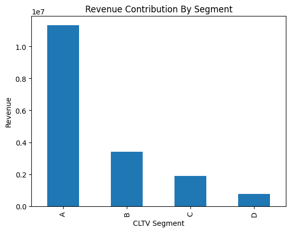

```python
# Revenue Contribution Visualization
segment_revenue.plot(kind="bar")

plt.title("Revenue Contribution By Segment")
plt.xlabel("CLTV Segment")
plt.ylabel("Revenue")

plt.show()
```

```python
# Average Revenue Per Customer By Segment
avg_revenue_segment = (
    cltv_df.groupby("CLTV_Segment")["Revenue"]
    .mean()
    .sort_values(ascending=False)
)

avg_revenue_segment
```

```
CLTV_Segment
A    7703.624605
B    2312.656312
C    1281.825048
D     523.934000
Name: Revenue, dtype: float64
```

```python
# Average Order Frequency By Segment
segment_orders = (
    cltv_df.groupby("CLTV_Segment")["Total_Orders"]
    .mean()
    .sort_values(ascending=False)
)

segment_orders
```

```
CLTV_Segment
A    8.734014
B    6.802587
C    5.656909
D    3.963946
Name: Total_Orders, dtype: float64
```

```python
# Average Order Value By Segment
segment_aov = (
    cltv_df.groupby("CLTV_Segment")["AOV"]
    .mean()
    .sort_values(ascending=False)
)

segment_aov
```

```
CLTV_Segment
A    854.428768
B    338.911400
C    225.498758
D    121.744336
Name: AOV, dtype: float64
```

```python
# Combined Segment Summary Table
segment_summary = pd.DataFrame({
    "Avg_Revenue": cltv_df.groupby("CLTV_Segment")["Revenue"].mean(),
    "Avg_Orders": cltv_df.groupby("CLTV_Segment")["Total_Orders"].mean(),
    "Avg_AOV": cltv_df.groupby("CLTV_Segment")["AOV"].mean(),
    "Avg_CLTV": cltv_df.groupby("CLTV_Segment")["CLTV"].mean()
})

segment_summary.sort_values("Avg_CLTV", ascending=False)
```

| CLTV_Segment | Avg_Revenue | Avg_Orders | Avg_AOV | Avg_CLTV |
| --- | --- | --- | --- | --- |
| A | 7703.624605 | 8.734014 | 854.428768 | 10865.444078 |
| B | 2312.656312 | 6.802587 | 338.911400 | 4309.806744 |
| C | 1281.825048 | 5.656909 | 225.498758 | 2867.581517 |
| D | 523.934000 | 3.963946 | 121.744336 | 1548.176187 |

```python
# Top 10 Customers By CLTV

# Identify the most valuable customers based on Customer Lifetime Value.
top_10_cltv = (
    cltv_df.sort_values(
        by="CLTV",
        ascending=False
    )
    .head(10)
)

top_10_cltv
```

|  | Customer ID | Revenue | Total_Orders | AOV | CLTV | CLTV_Segment |
| --- | --- | --- | --- | --- | --- | --- |
| 4061 | 16446.0 | 168472.50 | 2 | 84236.250000 | 1.071200e+06 | A |
| 3371 | 15749.0 | 44534.30 | 3 | 14844.766667 | 1.887752e+05 | A |
| 2722 | 15098.0 | 39916.50 | 3 | 13305.500000 | 1.692010e+05 | A |
| 1324 | 13687.0 | 11880.84 | 1 | 11880.840000 | 1.510841e+05 | A |
| 569 | 12918.0 | 10953.50 | 1 | 10953.500000 | 1.392915e+05 | A |
| 5642 | 18052.0 | 10877.18 | 1 | 10877.180000 | 1.383209e+05 | A |
| 3382 | 15760.0 | 13916.34 | 2 | 6958.170000 | 8.848439e+04 | A |
| 1538 | 13902.0 | 34095.26 | 5 | 6819.052000 | 8.671528e+04 | A |
| 0 | 12346.0 | 77556.46 | 12 | 6463.038333 | 8.218799e+04 | A |
| 11 | 12357.0 | 18287.66 | 3 | 6095.886667 | 7.751906e+04 | A |

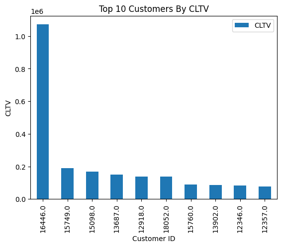

```python
# Top 10 Customers CLTV Visualization
top_10_cltv.plot(
    x="Customer ID",
    y="CLTV",
    kind="bar"
)

plt.title("Top 10 Customers By CLTV")
plt.ylabel("CLTV")

plt.show()
```

```python
# Top 10 Customers Revenue Contribution
top_10_cltv["Revenue"].sum()
```

```
np.float64(430490.54000000004)
```

```python
# Revenue Generated By Top 10 Customers (%)
round(
    (
        top_10_cltv["Revenue"].sum()
        /
        cltv_df["Revenue"].sum()
    ) * 100,
    2
)
```

```
np.float64(2.48)
```

```python
# Segment Wise Customer Count
segment_customer_count = (
    cltv_df.groupby("CLTV_Segment")
    ["Customer ID"]
    .count()
)

segment_customer_count
```

```
CLTV_Segment
A    1470
B    1469
C    1469
D    1470
Name: Customer ID, dtype: int64
```

```python
# Segment Wise Revenue Contribution
segment_revenue
```

```
CLTV_Segment
A    1.132433e+07
B    3.397292e+06
C    1.883001e+06
D    7.701830e+05
Name: Revenue, dtype: float64
```

```python
# Segment Wise CLTV Contribution
cltv_df.groupby("CLTV_Segment")["CLTV"].sum()
```

```
CLTV_Segment
A    1.597220e+07
B    6.331106e+06
C    4.212477e+06
D    2.275819e+06
Name: CLTV, dtype: float64
```

```python
# Key Business Findings
business_findings = pd.DataFrame({

    "Metric": [
        "Total Customers",
        "Top Segment",
        "Highest Revenue Segment",
        "Highest CLTV Segment"
    ],

    "Value": [
        cltv_df.shape[0],
        "A",
        "A",
        "A"
    ]

})

business_findings
```

|  | Metric | Value |
| --- | --- | --- |
| 0 | Total Customers | 5878 |
| 1 | Top Segment | A |
| 2 | Highest Revenue Segment | A |
| 3 | Highest CLTV Segment | A |

```python
# Pareto Analysis (80-20 Rule)

# Determine how many customers contribute to 80% of total revenue.
pareto_df = cltv_df.sort_values(
    by="Revenue",
    ascending=False
).reset_index(drop=True)

pareto_df["Cumulative_Revenue"] = (
    pareto_df["Revenue"].cumsum()
)

pareto_df["Cumulative_Percentage"] = (
    pareto_df["Cumulative_Revenue"]
    /
    pareto_df["Revenue"].sum()
) * 100

pareto_df.head()
```

|  | Customer ID | Revenue | Total_Orders | AOV | CLTV | CLTV_Segment | Cumulative_Revenue | Cumulative_Percentage |
| --- | --- | --- | --- | --- | --- | --- | --- | --- |
| 0 | 18102.0 | 580987.04 | 145 | 4006.807172 | 50953.035426 | A | 580987.04 | 3.343848 |
| 1 | 14646.0 | 528602.52 | 151 | 3500.678940 | 44516.796140 | A | 1109589.56 | 6.386199 |
| 2 | 14156.0 | 313437.62 | 156 | 2009.215513 | 25550.425762 | A | 1423027.18 | 8.190177 |
| 3 | 14911.0 | 291420.81 | 398 | 732.213090 | 9311.274022 | A | 1714447.99 | 9.867438 |
| 4 | 17450.0 | 244784.25 | 51 | 4799.691176 | 61035.838269 | A | 1959232.24 | 11.276284 |

```python
# Customers Required To Generate 80% Revenue
customers_80 = pareto_df[
    pareto_df["Cumulative_Percentage"] <= 80
]

customers_80.shape[0]
```

```
1353
```

```python
# Percentage Of Customers Generating 80% Revenue
round(
    customers_80.shape[0]
    /
    cltv_df.shape[0]
    * 100,
    2
)
```

```
23.02
```

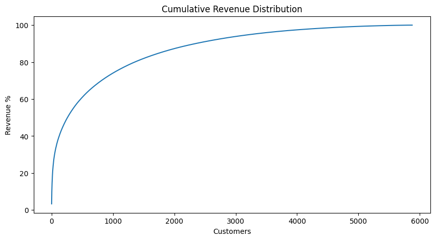

```python
# Revenue Distribution Curve
plt.figure(figsize=(10,5))

plt.plot(
    pareto_df["Cumulative_Percentage"]
)

plt.title(
    "Cumulative Revenue Distribution"
)

plt.xlabel("Customers")
plt.ylabel("Revenue %")

plt.show()
```

```python
# Strategic Recommendations
recommendations = pd.DataFrame({

    "Recommendation":[

        "Retain Segment A Customers",
        "Upsell Segment B Customers",
        "Engage Segment C Customers",
        "Reactivate Segment D Customers"

    ]

})

recommendations
```

|  | Recommendation |
| --- | --- |
| 0 | Retain Segment A Customers |
| 1 | Upsell Segment B Customers |
| 2 | Engage Segment C Customers |
| 3 | Reactivate Segment D Customers |

```python
# Final Business Summary Table
final_summary = pd.DataFrame({

    "Metric":[
        "Total Customers",
        "Total Revenue",
        "Average CLTV",
        "Top Segment"
    ],

    "Value":[
        cltv_df.shape[0],
        round(cltv_df["Revenue"].sum(),2),
        round(cltv_df["CLTV"].mean(),2),
        "A"
    ]

})

final_summary
```

|  | Metric | Value |
| --- | --- | --- |
| 0 | Total Customers | 5878 |
| 1 | Total Revenue | 17374804.27 |
| 2 | Average CLTV | 4898.2 |
| 3 | Top Segment | A |

```python
# Save Pareto Analysis Dataset
pareto_df.to_csv(
    r"C:\Users\LENOVO\Desktop\Saas-Ecommerce-cohort-retention-CLTV_Project\data\processed\pareto_analysis.csv",
    index=False
)

print("Pareto Dataset Saved")
```

```
Pareto Dataset Saved
```

```python
# Save Segment Summary Table
segment_summary.to_csv(
    r"C:\Users\LENOVO\Desktop\Saas-Ecommerce-cohort-retention-CLTV_Project\data\processed\segment_summary.csv",
    index=True
)

print("Segment Summary Saved")
```

```
Segment Summary Saved
```

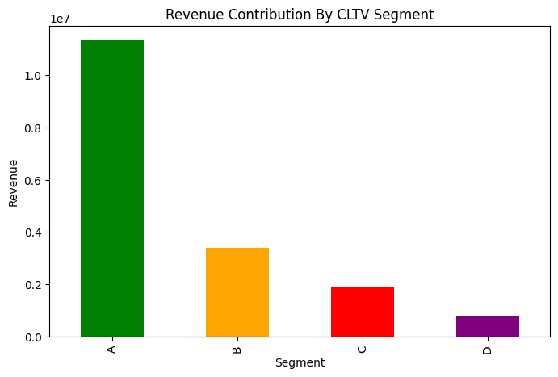

```python
# Revenue Contribution By CLTV Segment
# Revenue Contribution By Segment

segment_revenue = (
    cltv_df.groupby("CLTV_Segment")["Revenue"]
    .sum()
    .sort_values(ascending=False)
)

plt.figure(figsize=(8,5))

segment_revenue.plot(
    kind="bar",
    color=["green","orange","red","purple"]
)

plt.title("Revenue Contribution By CLTV Segment")
plt.xlabel("Segment")
plt.ylabel("Revenue")

plt.show()
```

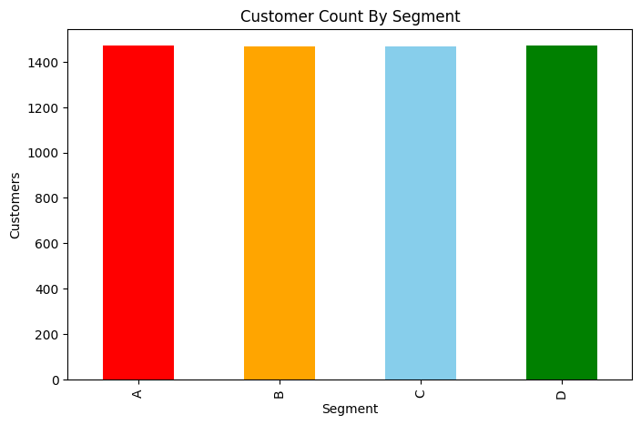

```python
# Customer Distribution Across Segments

segment_counts = (
    cltv_df["CLTV_Segment"]
    .value_counts()
    .sort_index()
)

plt.figure(figsize=(8,5))

segment_counts.plot(
    kind="bar",
    color=["red","orange","skyblue","green"]
)

plt.title("Customer Count By Segment")
plt.xlabel("Segment")
plt.ylabel("Customers")

plt.show()
```

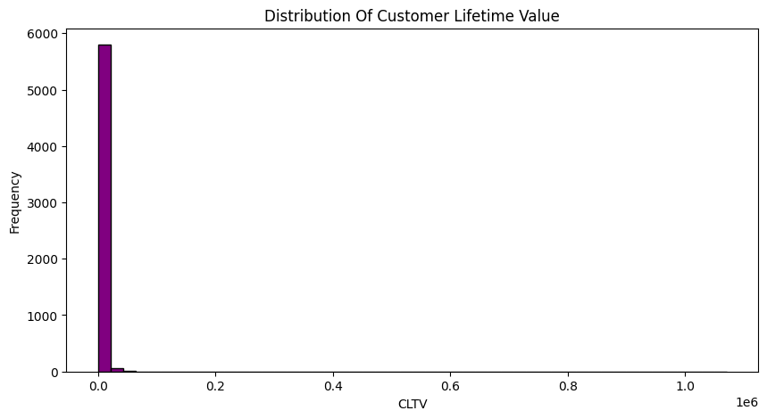

```python
# CLTV Distribution

plt.figure(figsize=(10,5))

plt.hist(
    cltv_df["CLTV"],
    bins=50,
    color="purple",
    edgecolor="black"
)

plt.title("Distribution Of Customer Lifetime Value")
plt.xlabel("CLTV")
plt.ylabel("Frequency")

plt.show()
```

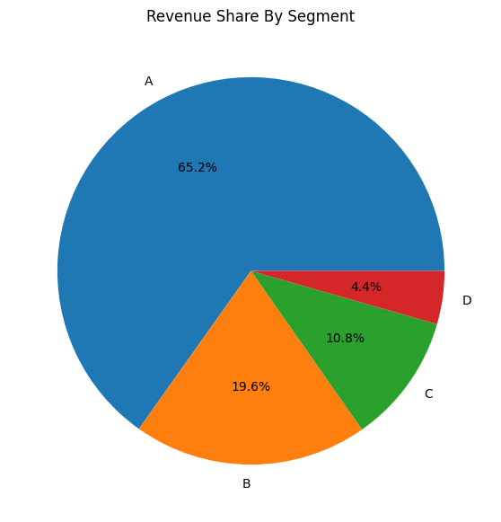

```python
# Revenue Share By Segment

segment_revenue = (
    cltv_df.groupby("CLTV_Segment")["Revenue"]
    .sum()
)

plt.figure(figsize=(7,7))

plt.pie(
    segment_revenue,
    labels=segment_revenue.index,
    autopct="%1.1f%%"
)

plt.title("Revenue Share By Segment")

plt.show()
```

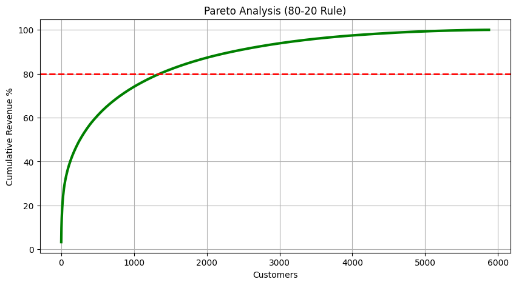

```python
# Pareto Analysis

plt.figure(figsize=(10,5))

plt.plot(
    pareto_df["Cumulative_Percentage"],
    color="green",
    linewidth=3
)

plt.axhline(
    y=80,
    color="red",
    linestyle="--",
    linewidth=2
)

plt.title("Pareto Analysis (80-20 Rule)")
plt.xlabel("Customers")
plt.ylabel("Cumulative Revenue %")

plt.grid(True)

plt.show()
```

```python
# cross check
import os

folder_path = r"C:\Users\LENOVO\Desktop\Saas-Ecommerce-cohort-retention-CLTV_Project\data\processed"

print(os.listdir(folder_path))
```

```
['cltv_base_data.csv', 'cohort_prepared_data.csv', 'customer_cltv_segments.csv', 'pareto_analysis.csv', 'retention_base_table.csv', 'retention_count_matrix.csv', 'retention_percentage_matrix.csv', 'segment_summary.csv']
```

# Customer Lifetime Value (CLTV) Analysis & Segmentation

## Objective

Calculate Customer Lifetime Value (CLTV) for each customer and segment customers into different value groups based on their purchasing behavior.

## Dataset Used

cltv_base_data.csv

Shape:

- Rows: 779,425
- Columns: 16

## Steps Performed

### 1. Loaded CLTV Base Dataset

- Imported processed dataset.
- Verified shape, columns and missing values.

### 2. Customer Level Aggregation

Calculated:

- Total Revenue
- Total Orders

for each customer.

### 3. Average Order Value (AOV)

Calculated:

AOV = Revenue / Total Orders

to measure customer spending behavior.

### 5. CLTV Segmentation

Customers were divided into:

- Segment A (Highest Value)
- Segment B
- Segment C
- Segment D (Lowest Value)

using quartile-based segmentation.

### 6. Segment Performance Analysis

Analyzed:

- Revenue Contribution
- Average Orders
- Average AOV
- Average CLTV

for each segment.

### 7. Pareto Analysis

Validated the 80/20 principle.

Key Finding: Approximately 23% of customers generated nearly 80% of total revenue.

### 8. Customer Strategy Recommendations

Created business recommendations for:

- Retain Segment A
- Upsell Segment B
- Engage Segment C
- Reactivate Segment D

### 9. Visualizations Created

- Revenue Contribution by Segment
- Customer Distribution by Segment
- CLTV Distribution
- Revenue Share Analysis
- Pareto Analysis

### 10. Exported Files

Saved:

- customer_cltv_segments.csv
- segment_summary.csv
- pareto_analysis.csv

for Power BI dashboard development.

## Key Findings

- Segment A generated over 65% of total revenue.
- Average CLTV across customers was approximately 4,898.
- Top customers contributed disproportionately to revenue.
- Around 23% of customers generated nearly 80% of revenue.

## Outcome

Successfully built a customer segmentation framework using CLTV analysis that can support retention, upselling, and targeted marketing strategies.